# Case Study 10

Hannah Cope

11/8/2021

#### Load Packages

```r
library(tidyquant)
library(tidyverse)
```

```r
library(lubridate)
library(dygraphs)
library(timetk)
library(ggplot2)
```

#### Pick different stocks

```r
tickers_today <- c("CXW", "F", "GM", "JCP", "KR", "WDC", "NKE","T", "WDAY", "WFC", "WMT")
```

#### Give the date range

```r
start <- today() - years(5)
end <- today()
```

### Stock price information for chosen stocks

```r
Interact <- tq_get(tickers_today, get = 'stock.prices', from = start, to = end)
```

### Plot of stock prices for chosen stocks

```r
Interact_plot <- Interact %>%
  select(symbol, date, adjusted) %>%
  pivot_wider(names_from = symbol, values_from = adjusted) %>%
  tk_xts(date_var = date)
dygraph(Interact_plot) %>%
  dyRangeSelector()
```

[interactive chart not shown]

### Monthly returns for chosen stocks

```r
My_monthlyReturns <- Interact %>%
  group_by(symbol) %>%
  tq_transmute(adjusted, mutate_fun = monthlyReturn) %>%
  select(symbol, date, monthly.returns) %>%
  pivot_wider(names_from = symbol, values_from = monthly.returns) %>%
  tk_xts(date_var = date)
```

```r
dygraph(My_monthlyReturns) %>%
  dyOptions(colors = RColorBrewer::brewer.pal(3, "Set2")) %>%
  dyRangeSelector()
```

[interactive chart not shown]

### Line plot of stock volumes

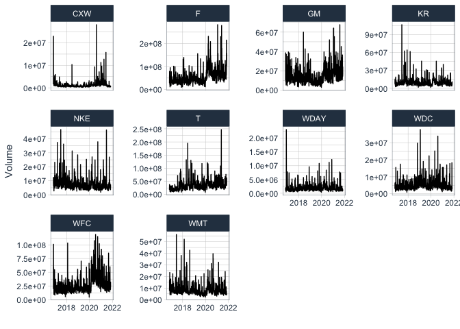

```r
Interact %>%
  ggplot(aes(x = date, y = volume)) +
  geom_line() +
  labs( y = "Volume",
        x = "") +
  facet_wrap(~ symbol, scale = "free_y") +
  theme_tq()
```

I chose to make a dygraph for the stock prices so that I could easily compare the different prices of the different stocks. I also added in the dyRangeSelector so that it could look closer at specific dates, such as highs and lows of the stock prices. For example, I was able to look at how the stock prices dropped in March becasue that is whenever COVID started to become a larger issue. I also decided to look into the monthly returns. It was interesting to see that they were so dispersed a year ago, but they are more bunched and similar as the year goes on. Also, it shows that during COVID, people were losing money in these stocks. Finally, I made a line plot to look at the volumes of the stock prices for the stocks. It was kind of hard to see, but from this graph I was able to note that Ford, and General Motors had upward trends in volume, so these are probably better ones to invest in.